# Reproducible Research: Peer Assessment 1

## Loading and preprocessing the data

```r
#unzip("activity.zip")
df <- read.csv("activity.csv")
library(stringr)
df$interval <- str_pad(df$interval, 4, pad="0")
#df$interval <- strptime(df$interval, "%H%M")
```

## What is mean total number of steps taken per day?

We first calculate the total number of steps per day.

```r
dailyTotals <- aggregate(steps ~ date, data=df, FUN=sum, na.action = na.omit)
```

Using these calculations, we can see that the mean of the total number of steps per day is **10766** and the medium is **10765**.

We can also see this in the following histogram:

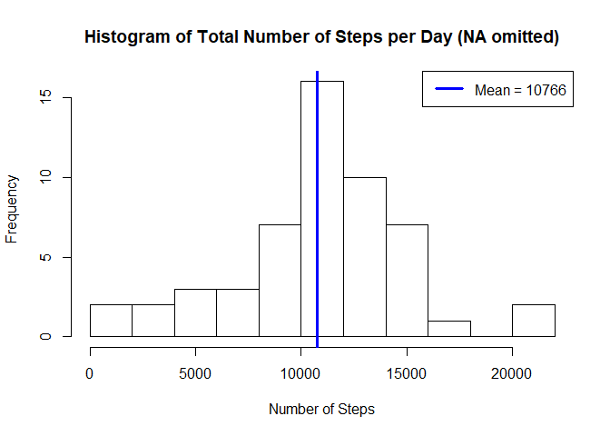

```r
hist(dailyTotals$steps, breaks=10, main="Histogram of Total Number of Steps per Day (NA omitted)", xlab="Number of Steps")
abline(v=mean(dailyTotals$steps), col="blue", lwd=3)
legend(x = "topright", legend=paste("Mean =", as.integer(mean(dailyTotals$steps))), col="blue", lty=1, lwd=3)
```

## What is the average daily activity pattern?

Now let’s see how the activity looks throughout the day. First we calculate the average number of steps for each 5-minute interval.

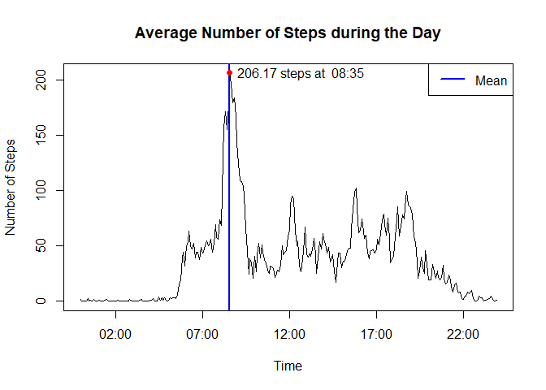

```r
intervalAverages <- aggregate(steps ~ interval, data = df[,c(1,3)], FUN=mean, na.action = na.omit)
#library(stringr)
#intervalAverages$interval <- str_pad(intervalAverages$interval, 4, pad="0")
intervalAverages$intervalFull <- strptime(intervalAverages$interval, "%H%M")
plot(x=intervalAverages$intervalFull, y=intervalAverages$steps, type="l", main="Average Number of Steps during the Day", xlab="Time", ylab="Number of Steps")
maxSteps <- max(intervalAverages$steps)
maxTime <- intervalAverages[which(grepl(max(intervalAverages$steps), intervalAverages$steps)),3]
abline(v=as.POSIXct(maxTime), col="blue", lwd=2)
points(x=maxTime, y=maxSteps, pch=19, col="red")
text(x=maxTime, y=maxSteps, paste(round(maxSteps, 2), "steps at ", format(maxTime, "%H:%M")), pos = 4)
legend(x="topright", legend="Mean", col="blue", lty=1, lwd=2)
```

As we can see, the **08:35** time interval contains the most number of steps, on average, across all the days in the dataset.

## Imputing missing values

There are **2304** observations in the dataset with missing values.

Let’s replace those missing values with the average steps for their respective interval.

```r
df2 <- df

for (i in 1:length(df2$interval)) {
  if (is.na(df2[i,1])) {
    df2[i,1] <- intervalAverages[which(grepl(df2[i,3], intervalAverages$interval)),2]
  }
}
head(df2)
```

```
##       steps       date interval
## 1 1.7169811 2012-10-01     0000
## 2 0.3396226 2012-10-01     0005
## 3 0.1320755 2012-10-01     0010
## 4 0.1509434 2012-10-01     0015
## 5 0.0754717 2012-10-01     0020
## 6 2.0943396 2012-10-01     0025
```

Now with the missing values filled with data, let’s see how this new dataset compares to the original dataset.

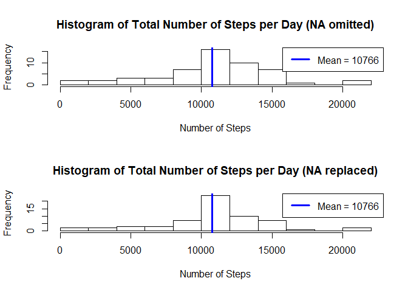

```r
dailyTotals2 <- aggregate(steps ~ date, data=df2, FUN=sum, na.action = na.omit)
par(mfcol=c(2,1))

hist(dailyTotals$steps, breaks=10, main="Histogram of Total Number of Steps per Day (NA omitted)", xlab="Number of Steps")
abline(v=mean(dailyTotals$steps), col="blue", lwd=3)
legend(x = "topright", legend=paste("Mean =", as.integer(mean(dailyTotals$steps))), col="blue", lty=1, lwd=3)

hist(dailyTotals2$steps, breaks=10, main="Histogram of Total Number of Steps per Day (NA replaced)", xlab="Number of Steps")
abline(v=mean(dailyTotals2$steps), col="blue", lwd=3)
legend(x = "topright", legend=paste("Mean =", as.integer(mean(dailyTotals2$steps))), col="blue", lty=1, lwd=3)
```

We can see that the mean of the total number of steps per day is **10766** and the medium is **10766**. The calculations with replaced missing values are practically the same as the calculatations with missing values omitted.

## Are there differences in activity patterns between weekdays and weekends?

As we see from the plots below, there are clear differences in the step activity for weekend vs weekday.

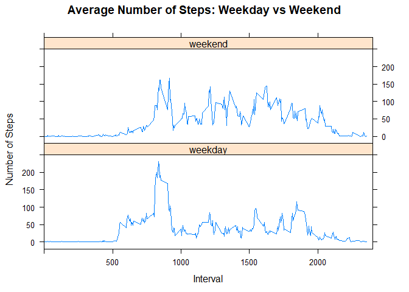

```r
# Add new column with day of the week
df2$weekday <- weekdays(as.Date(df2$date))

# Convert day of the week to weekday or weekend
df2$weekday <- lapply(df2$weekday, function(x){
  switch(x,
    "Saturday" = x <- "weekend",
    "Sunday" = x <- "weekend",
    x <- "weekday")
  return(x)
})

# Convert to a factor variable
df2$weekday <- factor(df2$weekday, levels = c("weekday", "weekend"))

#Calculate averages
weekdayIntervalAverages <- aggregate(steps ~ interval + weekday, data = df2[,c(1,3,4)], FUN=mean)

#plot
library(lattice)
xyplot(steps~interval | weekday, data=weekdayIntervalAverages, xlim=c(0,2400), ylim=c(-20,250), type="l", layout=c(1,2), xlab="Interval", ylab="Number of Steps", main="Average Number of Steps: Weekday vs Weekend")
```